# Independent Random Variables

March 24, 2020

Section 4.4

## Independent Events

Recall that two events, A and B, are independent if \( \small P(A\cap B) = P(A)P(B) \). We extend this concept for Random Variables.

*Definition.*

\( \small X \) and \( \small Y \) are **independent random variables** if the joint pmf of \( \small X \) and \( \small Y \) factors into the product of the marginal pmf of \( \small X \) times the marginal pmf of \( \small Y \).

This can be written

\[ P(X = x, Y=y) = P(X=x)P(Y=y) \quad \text{for all pairs of } (x,y) \]

or

\[ p_{X,Y}(x,y) = p_X(x)p_Y(y) \quad \text{for all pairs of } (x,y) \]

### Example 1

Let \( X \) and \( Y \) be random variables such that their joint pmf takes on the following table. Recall from Section 4.3.

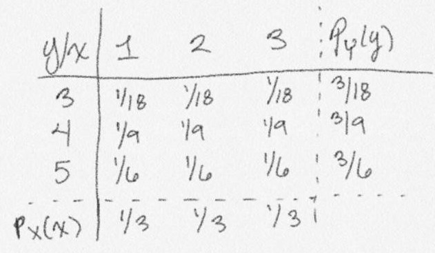

Observe that for each \( (x,y) \) pair, the product of the marginal pmfs is equivalent to the probability of the joint pmf. Thus, we can state that in this example \( X \) and \( Y \) are *independent*.

## Independent Random Variables

*Result.*

A necessary condition for two random variables to be independent is that the joint support for \( (X,Y) \) is the Cartesian product of the marginal support of \( X \), \( S_X \), and the marginal support of \( Y \), \( S_Y \). We can write,

\[ S_{X,Y} = S_X \times S_Y \]

Note that this condition is not sufficient, but gives a quick check for when random variables are dependent.

### Independent Random Variables Example

**Example 2.**

Suppose \( (X,Y) \) has the joint pmf \( p(x,y) = cxy \), where \( c \) is a real value. Let \( x \in S_X = \{1,2,3\} \) and \( y \in S_Y = \{1,2\} \)

**I.** For what value of c is this a well defined pmf?

\[ \sum\limits_{all x,y}p(x,y) = 1 \]

We are given the possible outcomes for both \( X \) and \( Y \). Working out the double some, observe

\[ \begin{aligned} 1 &= \sum\limits_{x=1}^{3}\sum\limits_{y=1}^2cxy = c\sum\limits_{x=1}^{3}\left(x\sum\limits_{y=1}^2y\right) \\ &= c\sum\limits_{x=1}^{3}3x = 3c(6) = 18c \\ \end{aligned} \]

Thus, we normalize this pmf such that it sums to 1. This implies that \( c = 1/18 \).

We can write the joint pmf for \( (X,Y) \) as

\[ p_{X,Y}(x,y) = \frac{xy}{18} 1_{S_X}(x) 1_{S_Y}(y) \]

### Example continued

**II.** Are \( X \) and \( Y \) independent?

We can start by checking the necessary condition. For this problem observe that

\[ S_{X,Y} = S_X\times S_Y \]

The joint support is the Cartesian product of the marginal supports, so we have the necessary condition for independence.

Method 1. Verify that \( p(x,y) = p_X(x)p_Y(y) \).

We can find the marginal pmfs for \( X \) and \( Y \) using the definition.

\[ p_X(x) = \sum\limits_{y=1}^{2}\frac{xy}{18} = \frac{x}{6}1_{S_X}(x) \]

Similarly,

\[ p_Y(y) = \sum\limits_{x=1}^{3}\frac{xy}{18} = \frac{y}{3}1_{S_Y}(y) \]

Thus, \( p(x,y) = p_X(x)p_Y(y) \) for all \( (x,y) \) pairs, so this satisfies the definition of independent random variables.

### Example continued

Method 2. For this problem, there is a small enough number of pairs, the pmf can be written as a table.

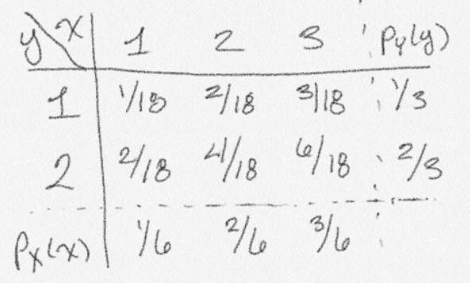

From the table it can be verified that \( p(x,y) = p_X(x)p_Y(y) \) for all \( (x,y) \) pairs.

How can we change this table to disrupt the independence?

[figure not shown]

This does not satisfy that for each pair \( (x,y) \) the joint pmf is not the product of the marginals.